# Comparing Predictive Non Linear Modelling For Air Quality Data of 4 US States for the year of 1987 & 2017

Ankita Guha and Kara Marsh

Loading a few libraries

```r
library(plyr)
library(dplyr)
```

```r
library(ggplot2)
library(useful)
library(coefplot)
library(caret)
library(lattice)
library(rpart)
library(rpart.plot)
library(RColorBrewer)
library(class)
library(randomForest)
library(reshape2)
library(glmnet)
```

**Data Preparation**

```r
aq4States1 <- read.table("data/eda2_States.csv", header = TRUE, sep = ",")
aq4States1$X <-NULL

aq4States <- aq4States1 %>%
  filter(year == "1987" | year == "2017")


# Creating Another Collumn With Pollutant as Binary Variable
nrow(na.omit(aq4States1))
```

```
## [1] 182878
```

```r
for(i in 1:nrow(aq4States)){
  if(aq4States$method_name[i] == "Ozone"){
    aq4States$Pollutant[i] <- 1
  }else{
    aq4States$Pollutant[i] <- 0
  }
}

aq4States$Pollutant <- as.factor(ifelse(aq4States$parameter_name=="Ozone",1,0))
str(aq4States)
```

```
## 'data.frame':    3361 obs. of  9 variables:
##  $ latitude               : num  32.7 36.7 33.9 34.3 34.9 ...
##  $ longitude              : num  -117 -120 -118 -119 -120 ...
##  $ parameter_name         : Factor w/ 789 levels "11122-Pentafluoroethane",..: 726 726 726 726 726 726 726 726 726 726 ...
##  $ method_name            : Factor w/ 474 levels "6L AMBIENT CANISTER - DUAL FID - PAMS",..: 205 205 205 205 205 205 205 205 205 205 ...
##  $ year                   : int  1987 1987 1987 1987 1987 1987 1987 1987 1987 1987 ...
##  $ arithmetic_mean        : num  20436 17618 3444 2561 2238 ...
##  $ arithmetic_standard_dev: num  8998 15073 1858 1265 666 ...
##  $ state_name             : Factor w/ 4 levels "Alabama","California",..: 2 2 2 2 2 2 2 2 2 2 ...
##  $ Pollutant              : Factor w/ 2 levels "0","1": 1 1 1 1 1 1 1 1 1 1 ...
```

```r
head(aq4States)
```

```
##   latitude longitude     parameter_name                     method_name
## 1 32.72727 -117.1545 Total hydrocarbons INSTRUMENTAL - FLAME IONIZATION
## 2 36.72523 -119.7513 Total hydrocarbons INSTRUMENTAL - FLAME IONIZATION
## 3 33.92899 -118.2107 Total hydrocarbons INSTRUMENTAL - FLAME IONIZATION
## 4 34.28040 -119.3146 Total hydrocarbons INSTRUMENTAL - FLAME IONIZATION
## 5 34.92442 -120.4018 Total hydrocarbons INSTRUMENTAL - FLAME IONIZATION
## 6 37.33967 -121.8886 Total hydrocarbons INSTRUMENTAL - FLAME IONIZATION
##   year arithmetic_mean arithmetic_standard_dev state_name Pollutant
## 1 1987       20435.528               8998.2441 California         0
## 2 1987       17617.544              15073.3133 California         0
## 3 1987        3443.692               1858.0015 California         0
## 4 1987        2560.900               1264.9616 California         0
## 5 1987        2237.532                666.1922 California         0
## 6 1987        2196.192                522.5010 California         0
```

```r
rm(aq4States1)
```

```r
aq4States$parameter_name <- NULL
aq4States$method_name <- NULL
str(aq4States)
```

```
## 'data.frame':    3361 obs. of  7 variables:
##  $ latitude               : num  32.7 36.7 33.9 34.3 34.9 ...
##  $ longitude              : num  -117 -120 -118 -119 -120 ...
##  $ year                   : int  1987 1987 1987 1987 1987 1987 1987 1987 1987 1987 ...
##  $ arithmetic_mean        : num  20436 17618 3444 2561 2238 ...
##  $ arithmetic_standard_dev: num  8998 15073 1858 1265 666 ...
##  $ state_name             : Factor w/ 4 levels "Alabama","California",..: 2 2 2 2 2 2 2 2 2 2 ...
##  $ Pollutant              : Factor w/ 2 levels "0","1": 1 1 1 1 1 1 1 1 1 1 ...
```

```r
summary(aq4States)
```

```
##     latitude       longitude            year      arithmetic_mean
##  Min.   :25.89   Min.   :-124.20   Min.   :1987   Min.   :   -6.133
##  1st Qu.:32.85   1st Qu.:-120.50   1st Qu.:1987   1st Qu.:    0.047
##  Median :34.95   Median :-117.12   Median :2017   Median :    1.561
##  Mean   :35.84   Mean   :-106.95   Mean   :2003   Mean   :   50.702
##  3rd Qu.:38.05   3rd Qu.: -94.48   3rd Qu.:2017   3rd Qu.:   14.078
##  Max.   :48.11   Max.   : -82.42   Max.   :2017   Max.   :20435.528
##  arithmetic_standard_dev      state_name   Pollutant
##  Min.   :    0.000       Alabama   : 236   0:2881
##  1st Qu.:    0.018       California:1845   1: 480
##  Median :    1.378       Michigan  : 545
##  Mean   :   19.556       Texas     : 735
##  3rd Qu.:    7.731
##  Max.   :15073.313
```

Now we’ll just take a subset of the columns as there are a few that contain the same information. Remember, the new column `Pollutant` is the one we are trying to predict.

```r
set.seed(828)
sample_size <- ceiling(0.30 * nrow(aq4States))
testrecs <- sample(nrow(aq4States),sample_size)
Ozone_test <- aq4States[testrecs,]
Ozone_train <- aq4States[-testrecs,]
```

```r
Ozone_LogM1 <- glm(Pollutant ~  .,
                    data=Ozone_train,
                   family=binomial(link="logit"),
                   control = list(maxit = 50))
summary(Ozone_LogM1)
```

```
##
## Call:
## glm(formula = Pollutant ~ ., family = binomial(link = "logit"),
##     data = Ozone_train, control = list(maxit = 50))
##
## Deviance Residuals:
##     Min       1Q   Median       3Q      Max
## -1.6019  -0.1011   0.0000   0.0000   2.3234
##
## Coefficients:
##                           Estimate Std. Error z value Pr(>|z|)
## (Intercept)              55.287355  10.861192   5.090 3.57e-07 ***
## latitude                 -0.058073   0.054970  -1.056   0.2908
## longitude                 0.056067   0.046213   1.213   0.2250
## year                     -0.024195   0.005221  -4.634 3.59e-06 ***
## arithmetic_mean          -0.858965   0.807980  -1.063   0.2877
## arithmetic_standard_dev -14.455825   2.653190  -5.448 5.08e-08 ***
## state_nameCalifornia      2.110993   1.463278   1.443   0.1491
## state_nameMichigan       -1.920893   0.750410  -2.560   0.0105 *
## state_nameTexas           0.813990   0.689282   1.181   0.2376
## ---
## Signif. codes:  0 '***' 0.001 '**' 0.01 '*' 0.05 '.' 0.1 ' ' 1
##
## (Dispersion parameter for binomial family taken to be 1)
##
##     Null deviance: 1943.5  on 2351  degrees of freedom
## Residual deviance: 1012.3  on 2343  degrees of freedom
## AIC: 1030.3
##
## Number of Fisher Scoring iterations: 23
```

Looks like our Model has fitted well, since the Residual deviance value is less than the value of Null deviance. Converting probabilities to 0 and 1 for predictions.

```r
yhat_LogM1 <- (Ozone_LogM1$fit > 0.5) * 1
```

Putting the fitted and the predicted values into a dataframe for ease of analysis

```r
Ozone_fit_predictions <- data.frame(Ozone_LogM1$y, yhat_LogM1)
names(Ozone_fit_predictions) <- c("yact","yhat_LogM1")
```

## Creating Confusion Matrix

```r
# Confusion Matrix
table(Ozone_fit_predictions$yact, Ozone_fit_predictions$yhat_LogM1)
```

```
##
##        0    1
##   0 1878  134
##   1  158  182
```

```r
# Percentage of Precision and Recall
prop.table(table(Ozone_fit_predictions$yact,
                 Ozone_fit_predictions$yhat_LogM1))
```

```
##
##              0          1
##   0 0.79846939 0.05697279
##   1 0.06717687 0.07738095
```

```r
cm_LogM1 <- confusionMatrix(Ozone_fit_predictions$yhat_LogM1,
                            Ozone_fit_predictions$yact,
                            positive = "1")

cm_LogM1
```

```
## Confusion Matrix and Statistics
##
##           Reference
## Prediction    0    1
##          0 1878  158
##          1  134  182
##
##                Accuracy : 0.8759
##                  95% CI : (0.8618, 0.8889)
##     No Information Rate : 0.8554
##     P-Value [Acc > NIR] : 0.002287
##
##                   Kappa : 0.4829
##  Mcnemar's Test P-Value : 0.178311
##
##             Sensitivity : 0.53529
##             Specificity : 0.93340
##          Pos Pred Value : 0.57595
##          Neg Pred Value : 0.92240
##              Prevalence : 0.14456
##          Detection Rate : 0.07738
##    Detection Prevalence : 0.13435
##       Balanced Accuracy : 0.73435
##
##        'Positive' Class : 1
##
```

Looks like our Model has an Accuracy of 87% and the Sensitivity or the Probability of True Positive is only 53% at the 95% confidence interval. And looks like our Confidence Interval is also a tight fit indicating that our Rsquare Value or our Accuracy of Model Fit is a good fit at 95% confidence interval.

## Predictions on Test Data for Model 1: Logistic Regression

```r
prob_LogM1 <- predict(Ozone_LogM1,
                      newdata=Ozone_test,
                      type="response",
                      se.fit=FALSE)

pred_LogM1 <- (prob_LogM1 > 0.5) * 1

head(pred_LogM1)
```

```
## 3185  641 3065 1545 2182 1438
##    0    0    0    0    1    0
```

Let’s free some of our Memory space

```r
rm(Ozone_LogM1)
```

**Simple Decision Tree**

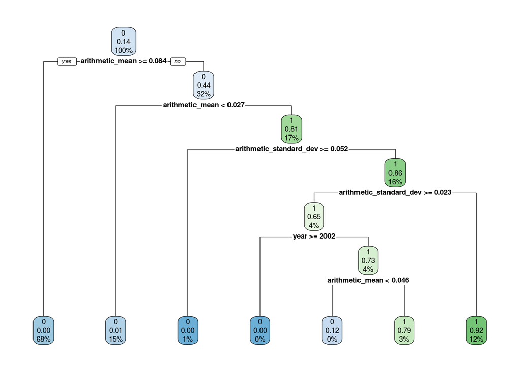

```r
Ozone_tree <- rpart(Pollutant ~ .,
                    data=Ozone_train,
                    method="class")

# Visualize the tree with rpart.plot
rpart.plot(Ozone_tree)
```

```r
## Creating Confusion Matrix

Ozone_fit_predictions$yhat_tree <- predict(Ozone_tree,
                                           type = "class")

# Confusion Matrix
table(Ozone_fit_predictions$yact,
      Ozone_fit_predictions$yhat_tree)
```

```
##
##        0    1
##   0 1973   39
##   1   10  330
```

```r
# Percentage of Precision and Recall
prop.table(table(Ozone_fit_predictions$yact,
                 Ozone_fit_predictions$yhat_tree))
```

```
##
##               0           1
##   0 0.838860544 0.016581633
##   1 0.004251701 0.140306122
```

```r
cm_tree <- confusionMatrix(Ozone_fit_predictions$yhat_tree,
                           Ozone_fit_predictions$yact,
                           positive = "1")
cm_tree
```

```
## Confusion Matrix and Statistics
##
##           Reference
## Prediction    0    1
##          0 1973   10
##          1   39  330
##
##                Accuracy : 0.9792
##                  95% CI : (0.9725, 0.9845)
##     No Information Rate : 0.8554
##     P-Value [Acc > NIR] : < 2.2e-16
##
##                   Kappa : 0.9186
##  Mcnemar's Test P-Value : 6.334e-05
##
##             Sensitivity : 0.9706
##             Specificity : 0.9806
##          Pos Pred Value : 0.8943
##          Neg Pred Value : 0.9950
##              Prevalence : 0.1446
##          Detection Rate : 0.1403
##    Detection Prevalence : 0.1569
##       Balanced Accuracy : 0.9756
##
##        'Positive' Class : 1
##
```

Looks like our Model has an Accuracy of 97% and the Sensitivity or the Probability of True Positive is also 97% at the 95% confidence interval. And looks like our Confidence Interval is also a tight fit indicating that our Rsquare Value or our Accuracy of Model Fit is a good fit at 95% confidence interval.

## Predictions on Test Data for Model 2: Simple Decision Tree

```r
pred_tree <- predict(Ozone_tree, newdata=Ozone_test, type="class")
head(pred_tree)
```

```
## 3185  641 3065 1545 2182 1438
##    0    0    0    0    0    0
## Levels: 0 1
```

# Model 3: Random Forest

```r
rand_forest <- randomForest(Pollutant ~ .,
                            data=Ozone_train,
                            method = "class")

rand_forest
```

```
##
## Call:
##  randomForest(formula = Pollutant ~ ., data = Ozone_train, method = "class")
##                Type of random forest: classification
##                      Number of trees: 500
## No. of variables tried at each split: 2
##
##         OOB estimate of  error rate: 1.74%
## Confusion matrix:
##      0   1 class.error
## 0 1985  27  0.01341948
## 1   14 326  0.04117647
```

## Creating Confusion Matrix

```r
Ozone_fit_predictions$yhat_rf <- predict(rand_forest,
                                         type = "class")

# Confusion matrix
table(Ozone_fit_predictions$yact,
      Ozone_fit_predictions$yhat_rf)
```

```
##
##        0    1
##   0 1985   27
##   1   14  326
```

```r
# Percentage of Precision and Recall
prop.table(table(Ozone_fit_predictions$yact,
                 Ozone_fit_predictions$yhat_rf))
```

```
##
##               0           1
##   0 0.843962585 0.011479592
##   1 0.005952381 0.138605442
```

```r
cm_rf <- confusionMatrix(Ozone_fit_predictions$yhat_rf,
                         Ozone_fit_predictions$yact,
                         positive = "1")

cm_rf
```

```
## Confusion Matrix and Statistics
##
##           Reference
## Prediction    0    1
##          0 1985   14
##          1   27  326
##
##                Accuracy : 0.9826
##                  95% CI : (0.9764, 0.9875)
##     No Information Rate : 0.8554
##     P-Value [Acc > NIR] : < 2e-16
##
##                   Kappa : 0.9306
##  Mcnemar's Test P-Value : 0.06092
##
##             Sensitivity : 0.9588
##             Specificity : 0.9866
##          Pos Pred Value : 0.9235
##          Neg Pred Value : 0.9930
##              Prevalence : 0.1446
##          Detection Rate : 0.1386
##    Detection Prevalence : 0.1501
##       Balanced Accuracy : 0.9727
##
##        'Positive' Class : 1
##
```

Looks like our Model has an Accuracy of 98% and the Sensitivity or the Probability of True Positive is 95% at the 95% confidence interval. And looks like our Confidence Interval is also a tight fit indicating that our Rsquare Value or our Accuracy of Model Fit is a good fit at 95% confidence interval.

## Predictions on Test Data for Model 3: Random Forest

```r
pred_rf <- predict(rand_forest,
                   newdata=Ozone_test,
                   type="class")

head(pred_rf)
```

```
## 3185  641 3065 1545 2182 1438
##    0    0    0    0    0    0
## Levels: 0 1
```

Then use the `predict()` function to make classification predictions on the test dataset and use `caret::confusionMatrix` to create a confusion matrix for each of the models for the predictions.

## Summarizing

Now let’s gather the three sets of prediction along with the actual values into its own dataframe.

```r
pred_results <- as.data.frame(cbind(pred_LogM1,
                                    pred_tree,
                                    pred_rf,
                                    Ozone_test$Pollutant))

names(pred_results) <- c("pred_LogM1", "pred_tree", "pred_rf","test_Pollutant")

head(pred_results)
```

```
##      pred_LogM1 pred_tree pred_rf test_Pollutant
## 3185          0         1       1              1
## 641           0         1       1              1
## 3065          0         1       1              1
## 1545          0         1       1              1
## 2182          1         1       1              1
## 1438          0         1       1              1
```

Hmmm, looks like the values are the level numbers. Let’s just adjust to match our logistic regression predictions for the rest of our Models.

```r
pred_results$pred_tree <- pred_results$pred_tree - 1
pred_results$pred_rf <- pred_results$pred_rf - 1
pred_results$test_Pollutant <- pred_results$test_Pollutant - 1
head(pred_results)
```

```
##      pred_LogM1 pred_tree pred_rf test_Pollutant
## 3185          0         0       0              0
## 641           0         0       0              0
## 3065          0         0       0              0
## 1545          0         0       0              0
## 2182          1         0       0              0
## 1438          0         0       0              0
```

Now let’s just create a confusion matrix for each model and the actual values from the Ozone_test dataset and compare their performance.

```r
cm_predLogM1 <- confusionMatrix(pred_results$pred_LogM1,
                                 pred_results$test_Pollutant,
                                 positive = "1")

cm_predtree <- confusionMatrix(pred_results$pred_tree,
                                pred_results$test_Pollutant,
                                positive = "1")

cm_predrf <- confusionMatrix(pred_results$pred_rf,
                                pred_results$test_Pollutant,
                                positive = "1")
```

## Confusion Matrix for Predicted Model 1: Logistic Regression

```r
cm_predLogM1
```

```
## Confusion Matrix and Statistics
##
##           Reference
## Prediction   0   1
##          0 813  67
##          1  56  73
##
##                Accuracy : 0.8781
##                  95% CI : (0.8563, 0.8977)
##     No Information Rate : 0.8612
##     P-Value [Acc > NIR] : 0.06457
##
##                   Kappa : 0.4726
##  Mcnemar's Test P-Value : 0.36723
##
##             Sensitivity : 0.52143
##             Specificity : 0.93556
##          Pos Pred Value : 0.56589
##          Neg Pred Value : 0.92386
##              Prevalence : 0.13875
##          Detection Rate : 0.07235
##    Detection Prevalence : 0.12785
##       Balanced Accuracy : 0.72849
##
##        'Positive' Class : 1
##
```

## Confusion Matrix for Predicted Model 2: Simple Decision Tree

```r
cm_predtree
```

```
## Confusion Matrix and Statistics
##
##           Reference
## Prediction   0   1
##          0 854   6
##          1  15 134
##
##                Accuracy : 0.9792
##                  95% CI : (0.9684, 0.9871)
##     No Information Rate : 0.8612
##     P-Value [Acc > NIR] : < 2e-16
##
##                   Kappa : 0.9152
##  Mcnemar's Test P-Value : 0.08086
##
##             Sensitivity : 0.9571
##             Specificity : 0.9827
##          Pos Pred Value : 0.8993
##          Neg Pred Value : 0.9930
##              Prevalence : 0.1388
##          Detection Rate : 0.1328
##    Detection Prevalence : 0.1477
##       Balanced Accuracy : 0.9699
##
##        'Positive' Class : 1
##
```

## Confusion Matrix for Predicted Model 3: Random Forest

```r
cm_predrf
```

```
## Confusion Matrix and Statistics
##
##           Reference
## Prediction   0   1
##          0 858   4
##          1  11 136
##
##                Accuracy : 0.9851
##                  95% CI : (0.9756, 0.9917)
##     No Information Rate : 0.8612
##     P-Value [Acc > NIR] : <2e-16
##
##                   Kappa : 0.9391
##  Mcnemar's Test P-Value : 0.1213
##
##             Sensitivity : 0.9714
##             Specificity : 0.9873
##          Pos Pred Value : 0.9252
##          Neg Pred Value : 0.9954
##              Prevalence : 0.1388
##          Detection Rate : 0.1348
##    Detection Prevalence : 0.1457
##       Balanced Accuracy : 0.9794
##
##        'Positive' Class : 1
##
```

## Accuracy & Sensitivity for all the Fitted Models

```r
# Model 1: Logistic Regression
sprintf("Model 1 - Logistic Regression: Accuracy = %8.4f Sensitivity = %8.4f",
        cm_LogM1$overall["Accuracy"],
        cm_LogM1$byClass["Sensitivity"])
```

```
## [1] "Model 1 - Logistic Regression: Accuracy =   0.8759 Sensitivity =   0.5353"
```

```r
# Model 2: Simple Decision Tree
sprintf("Model 2 - Simple Decision Tree: Accuracy = %8.4f Sensitivity = %8.4f",
        cm_tree$overall["Accuracy"],
        cm_tree$byClass["Sensitivity"])
```

```
## [1] "Model 2 - Simple Decision Tree: Accuracy =   0.9792 Sensitivity =   0.9706"
```

```r
# Model 3: Random Forest
sprintf("Model 3 - Random Forest: Accuracy = %8.4f Sensitivity = %8.4f",
        cm_rf$overall["Accuracy"],
        cm_rf$byClass["Sensitivity"])
```

```
## [1] "Model 3 - Random Forest: Accuracy =   0.9826 Sensitivity =   0.9588"
```

## Accuracy & Sensitivity for all the Predicted Models

```r
# Model 1: Logistic Regression
sprintf("Model 1 - Logistic Regression: Accuracy = %8.4f Sensitivity = %8.4f",
        cm_predLogM1$overall["Accuracy"],
        cm_predLogM1$byClass["Sensitivity"])
```

```
## [1] "Model 1 - Logistic Regression: Accuracy =   0.8781 Sensitivity =   0.5214"
```

```r
# Model 2: Simple Decision Tree
sprintf("Model 2 - Simple Decision Tree: Accuracy = %8.4f Sensitivity = %8.4f",
        cm_predtree$overall["Accuracy"],
        cm_predtree$byClass["Sensitivity"])
```

```
## [1] "Model 2 - Simple Decision Tree: Accuracy =   0.9792 Sensitivity =   0.9571"
```

```r
# Model 3: Random Forest
sprintf("Model 3 - Random Forest: Accuracy = %8.4f Sensitivity = %8.4f",
        cm_predrf$overall["Accuracy"],
        cm_predrf$byClass["Sensitivity"])
```

```
## [1] "Model 3 - Random Forest: Accuracy =   0.9851 Sensitivity =   0.9714"
```